# BACQUET Maxime et CARON Mathieu

# TP1b - Génération de variables aléatoires (Deuxième partie)

## Estimation avancée - G3 SDIA

Dans ce TP, on continue de s'intéresser à la génération de variables aléatoires. Ce TP se concentre sur la méthode acceptation-rejet, l'estimation de Monte Carlo, et l'échantillonnage d'importance.

### Instructions

1. Renommer votre notebook sous la forme `tp1a_Nom1_Nom2.ipynb`, et inclure le nom du binôme dans le notebook.
2. Votre code, ainsi que toute sortie du code, doivent être commentés !
3. Déposer votre notebook sur Moodle dans la section prévue à cet effet avant la date limite : 26 Novembre 2023, 23h59.

```python
import numpy as np
from matplotlib import pyplot as plt
```

### Partie 1 - Acceptation-Rejet (*Rejection sampling*)

NB : Toujours comparer les distributions empiriques obtenues aux densités théoriques à l'aide d'histogrammes ou de *kernel density estimates*.

**Q1 - Loi Bêta**. On considère la loi Bêta, dont la densité sur $[0,1]$ est $$f(x;\alpha, \beta) = \frac{\Gamma(\alpha + \beta)}{\Gamma(\alpha) \Gamma(\beta)} x^{\alpha-1} (1-x)^{\beta-1} \quad \alpha > 0, \quad \beta > 0.$$

On souhaite obtenir des échantillons de la loi Bêta dans le cas suivant : $\alpha = 2, \beta = 2$.

- Expiquer pourquoi il est difficile de mettre en place la méthode de la transformée inverse.
- Quelle loi très simple peut-on utiliser comme loi instrumentale ?
- Implémenter alors un algorithme acceptation-rejet pour obtenir $N = 10000$ échantillons.
- Comparer la proportion empirique d'échantillons acceptés avec sa valeur théorique.
- Quelle difficulté rencontre-t-on pour le cas $\alpha = 0.5, \beta = 0.5$ ?

## *Explication de pourquoi il est difficile de mettre en place la méthode de la transformée inverse*

Il est difficile de mettre en place la méthode de la transformée inverse pour la loi Beta ($\alpha = 2, \beta = 2$) en raison de la complexité de l'inversion de la fonction de répartition cumulative associée à cette distribution.

La pdf de la loi Beta est donnée par :

$f(x;\alpha, \beta) = \frac{\Gamma(\alpha + \beta)}{\Gamma(\alpha) \Gamma(\beta)} x^{\alpha-1} (1-x)^{\beta-1}$

La fonction de répartition cumulative associée est l'intégrale de la fonction de densité de probabilité :

$F(x;\alpha, \beta) = \int_0^x f(t;\alpha, \beta) \, dt$

Ainsi pour inverser la CDF et obtenir la transformée inverse, on doit résoudre $F(x) = u$ pour x, où u est une variable aléatoire uniforme. Cette équation ne peut pas être résolue de manière analytique de manière simple en termes de fonctions élémentaires.

Cela rend difficile la mise en place de la méthode de la transformée inverse.

## *Quelle loi très simple peut-on utiliser comme loi instrumentale ?*

Pour la loi Beta ($\alpha = 2, \beta = 2$), une loi très simple que l'on peut utiliser comme loi instrumentale est la loi uniforme sur l'intervalle $[0, 1]$.

La densité de probabilité de la loi uniforme sur $[0, 1]$ est constante sur cet intervalle, ce qui simplifie le processus d'acceptation-rejet. Ainsi en utilisant la loi uniforme comme loi instrumentale, on peut générer des échantillons aléatoires selon la méthode d'acceptation-rejet en comparant la densité de probabilité de la loi Beta avec la densité de probabilité de la loi uniforme.

## *Implémentation de l'algorithme acceptation-rejet pour obtenir $N = 10000$ échantillons*

```python
import scipy.stats as stats

# Paramètres de la loi Beta
alpha = 2
beta = 2
```

```python
# Fonction de densité de la loi Beta
def beta_density(x, alpha, beta):
    return stats.beta.pdf(x, alpha, beta)

# Fonction de la loi uniforme
def proposal_density(x):
    return stats.uniform.pdf(x)
```

```python
# Constante de normalisation M
M = 2.0

# Fonction de génération des échantillons par acceptation-rejet
def rejection_sampling(N):
    samples = []
    accepted_samples = []

    for _ in range(N):
        x = np.random.uniform(0, 1)
        u = np.random.uniform(0, M * proposal_density(x))

        if u <= beta_density(x, alpha, beta):
            accepted_samples.append(x)
        samples.append(x)

    return np.array(samples), np.array(accepted_samples)
```

```python
# Nombre d'échantillons
N = 10000

# On récupère donc nos échantillons avec la fonction de génération des échantillons par acceptation-rejet
samples, accepted_samples = rejection_sampling(N)

# Maintenant on peut calculer la proportion empirique d'échantillons acceptés
empirical_acceptance_ratio = len(accepted_samples) / N
print(f"Proportion empirique d'échantillons acceptés : {empirical_acceptance_ratio}")
```

```
Proportion empirique d'échantillons acceptés : 0.5014
```

## *Comparaison de la proportion empirique d'échantillons acceptés avec la valeur théorique*

La valeur théorique de la proportion d'échantillons acceptés est donnée par $ p = \frac{\text{surface sous la courbe de la loi Beta}}{\text{surface sous la courbe de la loi uniforme}} $

Pour la loi Beta(2,2), cette valeur est $ p = \frac{1}{2} $

## *Difficulté pour le cas α = 0.5, β = 0.5*

Le cas $\alpha = 0.5, \beta = 0.5$ pose problème car la fonction de densité de la loi Beta devient infinie à $x = 0$ et $x = 1$.

La présence de singularités rend difficile l'utilisation de la proposition uniforme (en tant que loi instrumentale) car elle ne peut pas envelopper les singularités aux extrémités de la distribution Beta($0.5, 0.5$). La loi uniforme n'est donc pas capable de générer des échantillons suffisamment proches de 0 et 1 pour couvrir ces zones problématiques.

**Q2 - Loi Gamma**. On considère la loi Gamma, dont la densité sur $\mathbb{R}_+$ est définie par $$f(x;\alpha,\beta) = \frac{\beta^\alpha}{\Gamma(\alpha)} exp(-\beta x) x^{\alpha - 1}.$$

Nous avons déjà vu en TD que si $X_1, ..., X_n$ sont des v.a. indépendantes de loi Exponentielle de paramètre $\beta$, alors $Y = \sum_{i=1}^n X_i$ suit une loi Gamma de paramètres $(n,\beta)$. Ceci nous permet de simuler de la loi Gamma quand $\alpha$ est entier, mais pas lorsque $\alpha$ n'est pas entier.

Dans ce cas, on va utiliser une loi Gamma $(\lfloor \alpha \rfloor, \beta - 1)$ comme loi instrumentale :

- Obtenir la formule de la valeur optimale de la constante *M*, puis la calculer numériquement
- Implémenter un algorithme acceptation-rejet pour générer 10000 échantillons de la loi Gamma avec les paramètres $\alpha = 2.5$ et $\beta = 1.5$.

## *Obtenir la formule de la valeur optimale de la constante* M*, puis la calculer numériquement*

La constante M dans la méthode d'acceptation-rejet est choisie de manière à ce que $M \cdot g(x) \geq f(x)$ pour tous les x dans le domaine d'intérêt, où $g(x)$ est la loi instrumentale. Dans notre cas, la loi instrumentale est une loi Gamma($\lfloor \alpha \rfloor, \beta - 1$)

On souhaite alors étudier le rapport $\frac{f(x)}{g(x)}$ et en déduire son maximum si il en admet un.

On a alors : $$ h'(x) = -exp(-x)\sqrt{x} + \frac{1}{2\sqrt{x}}exp(-x) $$ $$ \text{Et } h'(x) = 0 \text{ ssi } \sqrt(x) = \frac{1}{2\sqrt{x}} \text{ ssi } x = \frac{1}{2} $$

```
M = 3.556228846580734
```

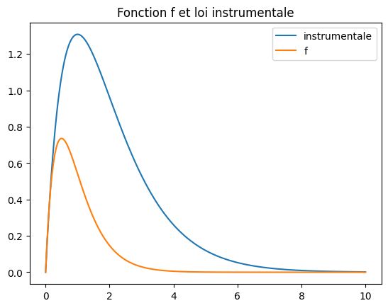

```python
import math

x = np.linspace(0, 10, 1000)
M = 1.5**(2.5)*math.gamma(2)/(math.gamma(2.5)* 0.5**2)*math.exp(-0.5) * np.sqrt(0.5)
print("M =",M)
instrumentale = M * stats.gamma.pdf(x, np.floor(alpha), scale = 1/(beta - 1))
f = stats.gamma.pdf(x, alpha, scale = 1/beta)

plt.plot(x, instrumentale, label = "instrumentale")
plt.plot(x, f, label = "f")
plt.title("Fonction f et loi instrumentale")
plt.legend()
plt.savefig("img/fonction_f_gamma_et_loi_instrumentale.png")
plt.show()
```

**Calcul numérique de la constante M**

```python
# Paramètres de la loi Gamma cible
alpha = 2.5
beta = 1.5

# Paramètres de la loi instrumentale (Gamma tronquée)
instrumental_alpha = np.floor(alpha)
instrumental_beta = beta - 1
```

#### *Implémentation de l'algorithme acceptation-rejet pour générer 10000 échantillons de la loi Gamma avec les paramètres $\alpha = 2.5$ et $\beta = 1.5$*

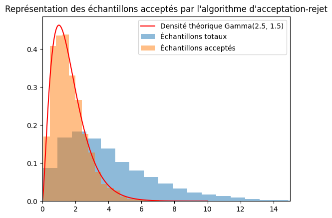

```python
# Génération des échantillons par acceptation-rejet
def rejection_sampling_gamma(N):
    samples = []
    accepted_samples = []

    for _ in range(N):
        x = np.random.gamma(instrumental_alpha, scale=1/(instrumental_beta))
        u = np.random.uniform(0, M * stats.gamma.pdf(x, instrumental_alpha, scale = 1/instrumental_beta))

        if u <= stats.gamma.pdf(x, alpha,scale =  1/beta):
            accepted_samples.append(x)
        samples.append(x)

    return np.array(samples), np.array(accepted_samples)

# Nombre d'échantillons
N = 10000

# Obtention des échantillons
samples, accepted_samples = rejection_sampling_gamma(N)

# Affichage des résultats (par exemple, un histogramme)
plt.hist(samples,bins=30, density=True, alpha=0.5, label='Échantillons totaux')
plt.hist(accepted_samples,bins=30, density=True, alpha=0.5, label='Échantillons acceptés')
x = np.linspace(0, 10, 1000)
plt.plot(x, stats.gamma.pdf(x, alpha,scale = 1/beta), 'r', label='Densité théorique Gamma(2.5, 1.5)')
plt.xlim((0,15))
plt.title("Représentation des échantillons acceptés par l'algorithme d'acceptation-rejet")
plt.legend()
plt.savefig("img/representation_echantilons_acceptes_par_algo_acceptation-rejet_loi_gamme.png")
plt.show()
```

Grâce à l'algorithme d'acceptation-rejet, on obtient les résultats voulus, c'est-à-dire une approximation de la loi de densité gamma.

**Q3 - Gaussienne tronquée**. On souhaite maintenant obtenir des échantillons d'une loi gaussienne tronquée, i.e., une loi normale restreinte à un certain intervalle (en 1D), ou un certain pavé de l'espace (pour le cas multivarié).

On considère le cas d'une gaussienne multivariée $\mathcal{N}(0, I_d)$ que l'on tronque sur le pavé $[-1,2]^d$. On prendra comme loi instrumentale la loi $\mathcal{N}(0, I_d)$ (i.e., non tronquée)

- Justifier ce choix de loi instrumentale.
- Pour le cas univarié ($d=1$), calculer numériquement la probabilité d'acceptation de l'algorithme acceptation-rejet. On pourra utiliser $\texttt{scipy.stats.cdf}$.
- Que devient cette probabilité pour $d=10$ ? $d=100$ ? Conclure quant à la faiblesse fondamentale de l'algorithme acceptation-rejet.

Cette loi instrumentale sera nécessairement supérieure ou égale à la loi gaussienne tronquée de mêmes paramètres, ce qui nous facilite donc la détermination de M et donc simplifie l'application de l'algorithme d'acceptation-rejet.

```python
from scipy.stats import norm
from scipy.integrate import quad

# Paramètres de la distribution tronquée
a, b = -1, 2

# Fonction de densité de la distribution cible (gaussienne tronquée)
def target_distribution(x):
    return (norm.pdf(x) * ((x >= a) & (x <= b)))
# Fonction de densité de la distribution instrumentale (gaussienne standard)
def instrumental_distribution(x):
    return norm.pdf(x)

# Calcul de la constante de normalisation pour la distribution cible
normalization_constant = 1 / (norm.cdf(b) - norm.cdf(a))

# Fonction de probabilité d'acceptation
def acceptance_probability(x):
    return target_distribution(x) / normalization_constant * instrumental_distribution(x)

probability_of_acceptance, _ = quad(acceptance_probability, a, b)
print("Probabilité d'acceptation :", probability_of_acceptance)
```

```
Probabilité d'acceptation : 0.2122193160506719
```

```python
probability_acceptance_multivariate_d10 = probability_of_acceptance**10

print(f"Probabilité d'acceptation pour le cas multivarié (d=10) : {probability_acceptance_multivariate_d10}")

probability_acceptance_multivariate_d100 = probability_of_acceptance**100

print(f"Probabilité d'acceptation pour le cas multivarié (d=100) : {probability_acceptance_multivariate_d100}")
```

```
Probabilité d'acceptation pour le cas multivarié (d=10) : 1.8528877299829366e-07
Probabilité d'acceptation pour le cas multivarié (d=100) : 4.7696998874496544e-68
```

Dans le cas de la gaussienne tronquée multivariée $\mathcal{N}(0, I_d)$ tronquée sur le pavé $[-1, 2]^d$, la probabilité d'acceptation devient extrêmement faible à mesure que $d$ augmente. L'algorithme d'acceptation-rejet souffre de la "malédiction de la dimension", ce qui signifie que sa performance diminue considérablement avec l'augmentation de la dimension de l'espace. En conclusion, l'algorithme d'acceptation-rejet peut devenir inefficace et impraticable pour des distributions tronquées en haute dimension.

## Partie 2 - Estimation de $\pi$ par Monte Carlo

On rappelle que $\pi$ est égal à la surface d'un cercle de rayon 1, i.e. $$ \pi = \int_{-1}^1 \int_{-1}^1 \mathbb{1}_{x^2 + y^2 \leq 1}(x,y) dx dy.$$

Ce qui peut se réécrire comme $$ \pi = 4 \int_{-1}^1 \int_{-1}^1 \mathbb{1}_{x^2 + y^2 \leq 1}(x,y) p(x) p(y) dx dy.$$ Où $p(x)$ et $p(y)$ sont les densités de la loi uniforme sur $[-1,1]$.

- En déduire l'esimtateur de Monte Carlo de $\pi$.
- Représenter l'évolution de la valeur de l'estimation par Monte Carlo de $\pi$ en fonction du nombre d'échantillons (aller jusqu'à 10000). Quel résultat mathématique fondamental est-on en train d'illustrer ?
- (Bonus) - Faire 100 simulations de l'estimation par Monte Carlo de $\pi$ avec $N = 1000$ échantillons, et vérifier le résultat de convergence en loi de l'estimateur MC donné par le TCL.

L'estimateur de Monte Carlo de $\pi$ peut être obtenu en approximant l'intégrale définissant $\pi$ par la moyenne d'échantillons aléatoires. Plus précisément, en utilisant la loi uniforme sur l'intervalle $[-1, 1]$ pour générer des échantillons aléatoires pour $x$ et $y$, on peut estimer $\pi$ comme suit: $$ \hat{\pi} = 4 \cdot \frac{1}{N} \sum_{i=1}^{N} \mathbb{1}_{x_i^2 + y_i^2 \leq 1} $$ où $N$ est le nombre d'échantillons, et $(x_i, y_i)$ sont les échantillons générés à partir de la loi uniforme sur $[-1, 1]$.

En d'autres termes, pour chaque échantillon $(x_i, y_i)$, on évalue si $(x_i^2 + y_i^2 \leq 1)$ est vrai ou faux, et on prend la moyenne de ces évaluations. Multiplier par 4 est nécessaire pour compenser la réduction de la région d'intégration de $[-1,1]^2$ à la région du cercle de rayon 1.

Cet estimateur converge vers la vraie valeur de $\pi$ à mesure que le nombre d'échantillons $N$ augmente en accord avec la loi des grands nombres.

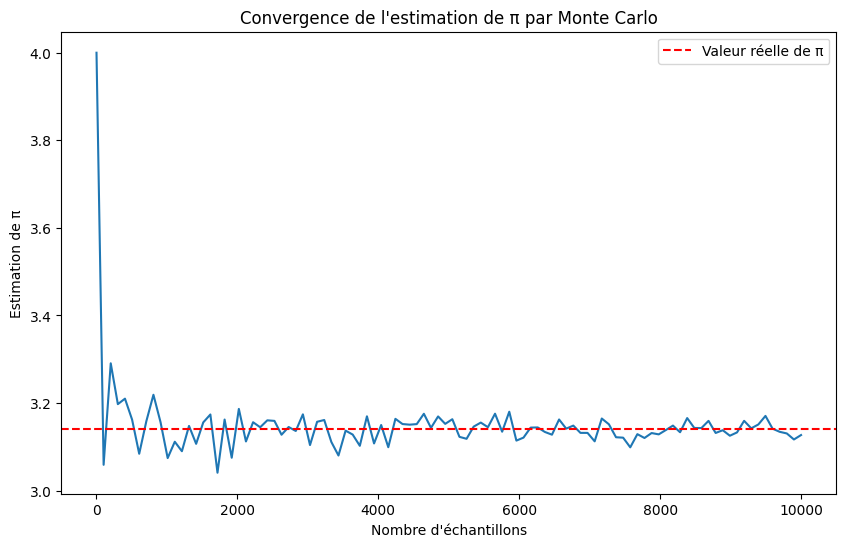

```python
def pi_estimator(num_samples):
    # Générer des coordonnées aléatoires dans l'intervalle [-1, 1]
    x = np.random.uniform(-1, 1, num_samples)
    y = np.random.uniform(-1, 1, num_samples)

    # Calculer la distance par rapport à l'origine
    distance = np.sqrt(x**2 + y**2)

    # Compter le nombre de points à l'intérieur du cercle de rayon 1
    inside_circle = np.sum(distance <= 1)

    # Estimation de π
    return 4 * inside_circle / num_samples

pi_values = []
# Nombre d'échantillons par simulation
num_samples = 10000

samples = np.linspace(1, num_samples, 100)

for sample in samples:
    pi_values.append(pi_estimator(int(sample)))

plt.figure(figsize=(10, 6))
plt.plot(samples, pi_values)
plt.axhline(np.pi, color='red', linestyle='--', label='Valeur réelle de π')
plt.xlabel('Nombre d\'échantillons')
plt.ylabel('Estimation de π')
plt.legend()
plt.title('Convergence de l\'estimation de π par Monte Carlo')
plt.savefig("img/convergence_estimation_de_pi_par_monte_carlo.png")
plt.show()
```

On peut voir que notre estimateur converge bien vers $\pi$ à l'aide du graphe précédent.

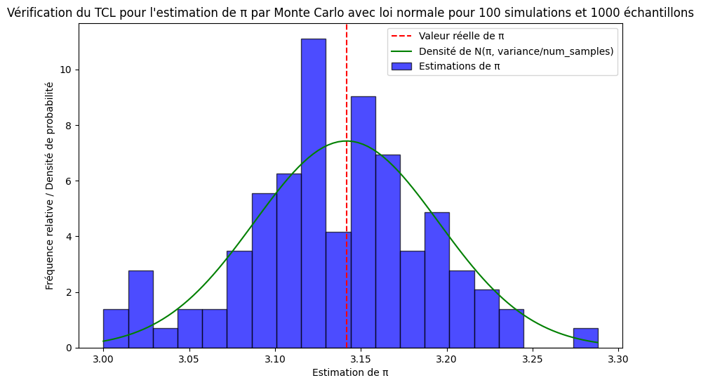

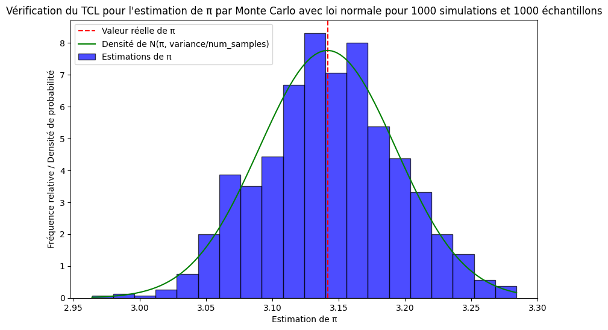

```python
def TCL_verification(num_simulations, num_samples):
    # Initialiser un tableau pour stocker les estimations de π de chaque simulation
    pi_estimates = np.zeros(num_simulations)

    # Simulation de Monte Carlo
    for i in range(num_simulations):
        pi_estimates[i] = pi_estimator(num_samples)

    # Vérification du TCL en représentant l'histogramme des estimations
    plt.figure(figsize=(10, 6))
    plt.hist(pi_estimates, bins=20, density=True, alpha=0.7, color='blue', edgecolor='black', label='Estimations de π')
    plt.axvline(np.pi, color='red', linestyle='--', label='Valeur réelle de π')

    # Ajouter la courbe de densité de probabilité d'une loi normale N(pi, variance/num_samples)
    variance_estimate = np.var(pi_estimates)
    std_dev_estimate = np.sqrt(variance_estimate)
    x_values = np.linspace(np.min(pi_estimates), np.max(pi_estimates), 100)
    pdf_values = norm.pdf(x_values, np.pi, std_dev_estimate)
    plt.plot(x_values, pdf_values, label='Densité de N(π, variance/num_samples)', color='green')

    plt.xlabel('Estimation de π')
    plt.ylabel('Fréquence relative / Densité de probabilité')
    plt.legend()
    plt.title('Vérification du TCL pour l\'estimation de π par Monte Carlo avec loi normale pour '+ str(num_simulations) + ' simulations et '+ str(num_samples) + ' échantillons')
    plt.savefig("img/verification_TCL_pour_estimation_π_par_Monte_Carlo_avec_loi_normale_pour_" + str(num_simulations) + '_simulations_et_'+ str(num_samples) + '_échantillons')
    plt.show()

TCL_verification(100, 1000)
TCL_verification(1000, 1000)
```

On peut voir que pour 100 simulations, la répartition des valeurs de $\pi$ commence à ressembler à la représentation d'une loi normale d'espérance $\pi$.

En augmentant le nombre de simulations à 1000, on peut voir que la similarité avec la représentation d'une loi normale est beaucoup plus flagrante, ce qui confirme bien le résultat de convergence en loi du théorème centrale limite.

En effet, plus le nombre de simulations réalisées sera important, plus la répartition des valeurs de $\pi$ tendra vers une loi normale.

### Partie 3 - Échantillonnage d'importance (*Importance sampling*)

On cherche à estimer $\mathbb{P}(X > 3)$ pour $X \sim \mathcal{N}(0,1)$.

- Ré-écrire cette probabilité comme une intégrale et en déduire l'estimateur de Monte Carlo "standard"
- Simuler $100$ fois $N = 10000$ échantillons, et donner la moyenne et la variance empiriques de l'estimateur de Monte Carlo standard
- On souhaite maintenant implémenter un schéma d'échantillonnage d'importance en utilisant comme loi instrumentale $\mathcal{N}(4,1)$. Donner l'estimateur de Monte Carlo associé.
- De même, simuler $100$ fois $N = 10000$ échantillons, et donner la moyenne et la variance empiriques de de deuxième estimateur.
- Quantifier la réduction de variance. Pouvait-on s'attendre à ce résultat ?

Pour estimer la probabilité $ \mathbb{P}(X > 3) $ pour $ X \sim \mathcal{N}(0,1) $ à l'aide de la méthode de Monte Carlo, on peut réécrire cette probabilité comme une intégrale:

$$ \mathbb{P}(X > 3) = \int_{3}^{\infty} \frac{1}{\sqrt{2\pi}} e^{-\frac{x^2}{2}} \,dx $$

L'estimateur de Monte Carlo "standard" de cette probabilité peut être formulé comme suit:

$$ \hat{P} = \frac{1}{N} \sum_{i=1}^{N} \mathbb{1}_{X_i > 3} $$

où $X_i$ sont des échantillons indépendants tirés de la distribution $ \mathcal{N}(0,1) $, et $ \mathbb{1}_{X_i > 3} $ est une fonction indicatrice qui vaut 1 si $X_i > 3$ et 0 sinon.

En d'autres termes, on génère $N$ échantillons aléatoires de $ X \sim \mathcal{N}(0,1) $, et on estime la probabilité $ \mathbb{P}(X > 3) $ en calculant la proportion de ces échantillons qui sont supérieurs à 3.

```python
# Paramètres
num_simulations = 100
num_samples = 10000

# Simulation de Monte Carlo standard
estimates_standard = np.zeros(num_simulations)

for i in range(num_simulations):
    samples = np.random.normal(0, 1, num_samples)
    estimates_standard[i] = np.mean(samples > 3)

# Moyenne et variance empiriques
mean_standard = np.mean(estimates_standard)
variance_standard = np.var(estimates_standard)

print("Estimateur de Monte Carlo standard:")
print(f"Moyenne empirique: {mean_standard}")
print(f"Variance empirique: {variance_standard}")
```

```
Estimateur de Monte Carlo standard:
Moyenne empirique: 0.00132
Variance empirique: 1.2059999999999995e-07
```

```python
# Paramètres de simulation
N = 10000
num_simulations = 100

# Fonctions de densité
def target_density(x):
    return norm.pdf(x)

def instrumental_density(x):
    return norm.pdf(x, loc=4, scale=1)

# Simulation et calcul de l'estimateur avec échantillonnage d'importance
def importance_sampling_estimator(N, target_density, instrumental_density):
    samples = np.random.normal(loc=4, scale=1, size=N)
    weights = target_density(samples) / instrumental_density(samples)
    indicator = (samples > 3).astype(int)
    estimate = np.mean(weights * indicator)
    return estimate

# Simulations
estimates_IS = [importance_sampling_estimator(N, target_density, instrumental_density) for _ in range(num_simulations)]

# Calcul des statistiques empiriques
mean_estimate_IS = np.mean(estimates_IS)
var_estimate_IS = np.var(estimates_IS)

print("Estimateur de Monte Carlo avec échantillonage d'importance:")
print(f"Moyenne empirique: {mean_estimate_IS}")
print(f"Variance empirique: {var_estimate_IS}")
```

```
Estimateur de Monte Carlo avec échantillonage d'importance:
Moyenne empirique: 0.0013460128168270053
Variance empirique: 1.0138149086509309e-09
```

La réduction de variance peut être quantifiée en comparant les variances empiriques des deux estimateurs. La formule pour la réduction de variance (RV) est donnée par :

$RV = 1 - \frac{\text{Var}(\hat{p}_{\text{IS}})}{\text{Var}(\hat{p})}$

```python
print(f"RV = {1 - var_estimate_IS/variance_standard}")
```

```
RV = 0.9915935745551332
```

On pouvait s'attendre à une réduction de variance car l'échantillonnage d'importance favorise la génération d'échantillons dans les régions où la fonction à estimer a une plus grande influence, ce qui peut conduire à une meilleure précision de l'estimation.